# Movie Dataset Analysis

2026-03-09

This report analyzes 58,788 IMDb movies from the `ggplot2movies` dataset. We clean, explore, visualize, and model the data to uncover what makes a movie highly rated.

```r
library(ggplot2movies)
library(ggplot2)
library(dplyr)
library(tidyr)

data(movies)
head(movies)
```

```
## # A tibble: 6 × 24
##   title      year length budget rating votes    r1    r2    r3    r4    r5    r6
##   <chr>     <int>  <int>  <int>  <dbl> <int> <dbl> <dbl> <dbl> <dbl> <dbl> <dbl>
## 1 $          1971    121     NA    6.4   348   4.5   4.5   4.5   4.5  14.5  24.5
## 2 $1000 a …  1939     71     NA    6      20   0    14.5   4.5  24.5  14.5  14.5
## 3 $21 a Da…  1941      7     NA    8.2     5   0     0     0     0     0    24.5
## 4 $40,000    1996     70     NA    8.2     6  14.5   0     0     0     0     0
## 5 $50,000 …  1975     71     NA    3.4    17  24.5   4.5   0    14.5  14.5   4.5
## 6 $pent      2000     91     NA    4.3    45   4.5   4.5   4.5  14.5  14.5  14.5
## # ℹ 12 more variables: r7 <dbl>, r8 <dbl>, r9 <dbl>, r10 <dbl>, mpaa <chr>,
## #   Action <int>, Animation <int>, Comedy <int>, Drama <int>,
## #   Documentary <int>, Romance <int>, Short <int>
```

```r
dim(movies)
```

```
## [1] 58788    24
```

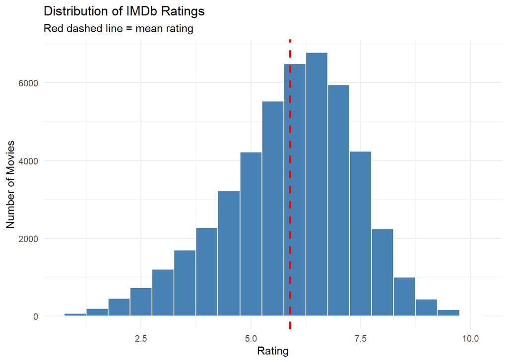

```r
movies_clean <- movies %>%
  filter(!is.na(rating), !is.na(length)) %>%
  filter(length>=1 & length<=300)%>%
  filter (votes>=10)

ggplot(movies_clean, aes(x = rating)) +
  geom_histogram(binwidth = 0.5, fill = "steelblue", color = "white") +
  geom_vline(aes(xintercept = mean(rating)), color = "red", linetype = "dashed", linewidth = 1) +
  labs(title = "Distribution of IMDb Ratings",
       subtitle = "Red dashed line = mean rating",
       x = "Rating", y = "Number of Movies") +
  theme_minimal()
```

We filtered out movies with missing values, unrealistic lengths, and fewer than 10 votes — leaving 46,939 reliable entries.

Ratings follow a roughly normal distribution centered around 6, suggesting most movies are perceived as average by audiences.

```r
genre_summary <- movies_clean %>%
  select(rating, Action, Animation, Comedy, Drama, Documentary, Romance, Short) %>%
  pivot_longer(cols = -rating, names_to = "genre", values_to = "is_genre") %>%
  filter(is_genre == 1) %>%
  group_by(genre) %>%
  summarise(
    count = n(),
    avg_rating = mean(rating)
  )

genre_summary
```

```
## # A tibble: 7 × 3
##   genre       count avg_rating
##   <chr>       <int>      <dbl>
## 1 Action       4203       5.27
## 2 Animation    2883       6.65
## 3 Comedy      14717       5.95
## 4 Documentary  2412       6.59
## 5 Drama       18531       6.15
## 6 Romance      4217       6.17
## 7 Short        6149       6.48
```

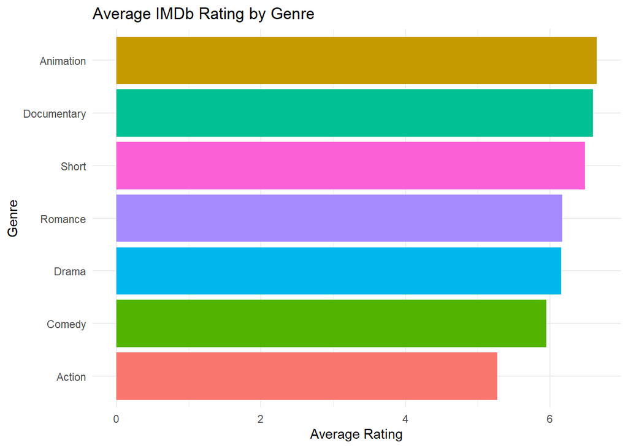

```r
ggplot(genre_summary, aes(x = reorder(genre, avg_rating), y = avg_rating, fill = genre)) +
  geom_col(show.legend = FALSE) +
  coord_flip() +
  labs(title = "Average IMDb Rating by Genre",
       x = "Genre", y = "Average Rating") +
  theme_minimal()
```

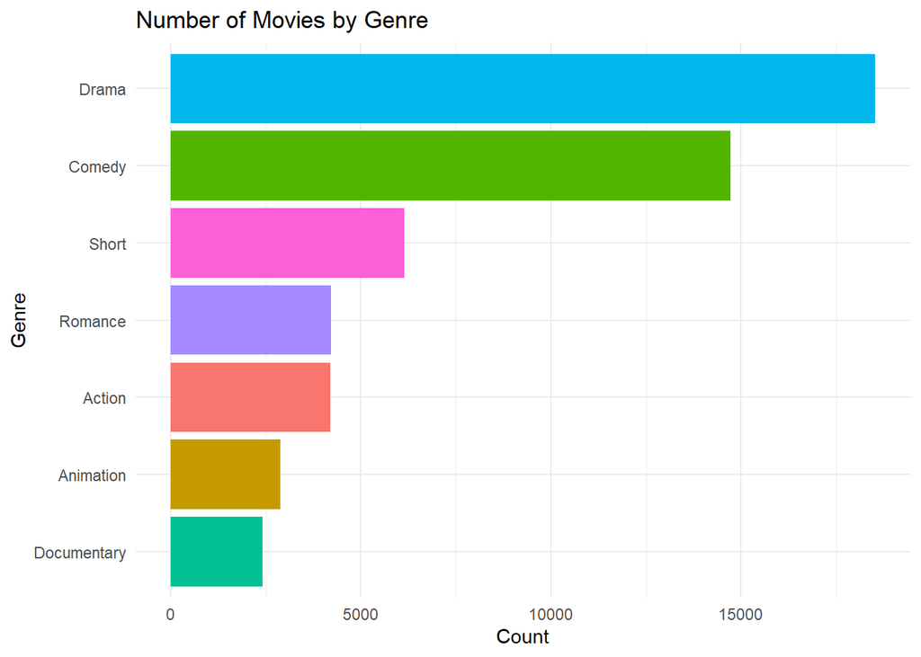

```r
ggplot(genre_summary, aes(x = reorder(genre, count), y = count, fill = genre)) +
  geom_col(show.legend = FALSE) +
  coord_flip() +
  labs(title = "Number of Movies by Genre",
       x = "Genre", y = "Count") +
  theme_minimal()
```

Drama is the most common genre, but Animation earns the highest average rating — likely due to survivorship bias among niche films.

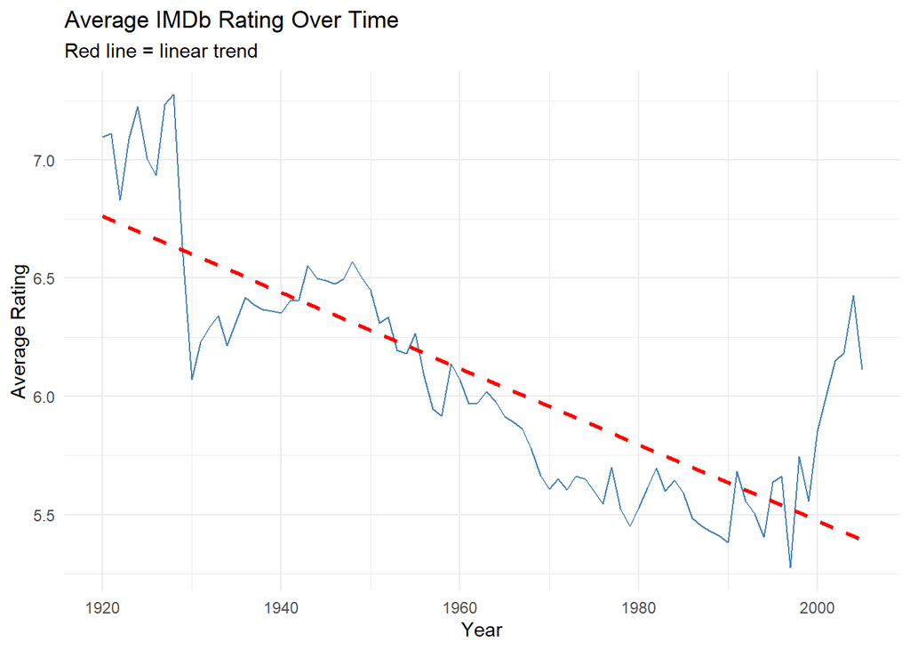

```r
movies_clean %>%
  filter(year >= 1920 & year <= 2005) %>%
  group_by(year) %>%
  summarise(avg_rating = mean(rating), count = n()) %>%
  ggplot(aes(x = year, y = avg_rating)) +
  geom_line(color = "steelblue") +
  geom_smooth(method = "lm", color = "red", linetype = "dashed", se = FALSE) +
  labs(title = "Average IMDb Rating Over Time",
       subtitle = "Red line = linear trend",
       x = "Year", y = "Average Rating") +
  theme_minimal()
```

[figure not shown]

```r
movies_clean %>%
  filter(!is.na(budget), budget > 0) %>%
  ggplot(aes(x = log10(budget), y = rating)) +
  geom_hex(bins = 30) +
  geom_smooth(method = "lm", color = "red", se = TRUE) +
  scale_fill_gradient(low = "lightblue", high = "darkblue") +
  labs(title = "Does Budget Predict Rating?",
       subtitle = "Darker = more movies in that area",
       x = "Budget (log10 scale)", y = "IMDb Rating") +
  theme_minimal()
```

With a correlation of just 0.02, budget has virtually no relationship with rating. Big budgets don’t guarantee good movies.

```r
movies_clean %>%
  filter(!is.na(budget), budget > 0) %>%
  summarise(correlation = cor(log10(budget), rating))
```

```
## # A tibble: 1 × 1
##   correlation
##         <dbl>
## 1      0.0213
```

[figure not shown]

```r
model <- lm(rating ~ length + votes + Action + Comedy + Drama + Romance + Animation,
            data = movies_clean)

library(broom)

tidy(model) %>%
  filter(term != "(Intercept)") %>%
  ggplot(aes(x = reorder(term, estimate), y = estimate,
             fill = estimate > 0)) +
  geom_col(show.legend = FALSE) +
  geom_errorbar(aes(ymin = estimate - std.error,
                    ymax = estimate + std.error), width = 0.3) +
  coord_flip() +
  scale_fill_manual(values = c("red", "steelblue")) +
  labs(title = "What Predicts a Movie's IMDb Rating?",
       subtitle = "Blue = positive effect, Red = negative effect",
       x = "", y = "Effect on Rating") +
  theme_minimal()
```

Our model confirms that genre is the strongest predictor of rating. Animation boosts ratings significantly while Action hurts them.

## Conclusion

This analysis of 46,939 IMDb movies reveals three key findings: genre is the strongest predictor of rating, budget has almost no effect, and older movies tend to rate higher due to survivorship bias.